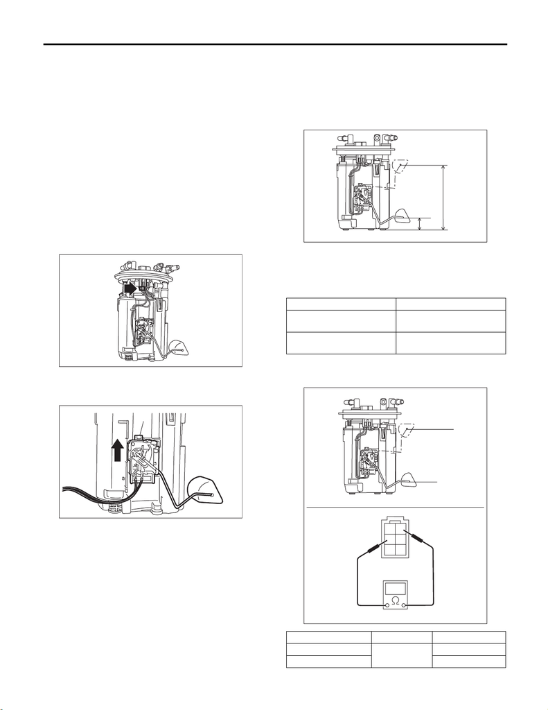

Fuel Level Sensor

FUEL INJECTION (FUEL SYSTEMS)

30.Fuel Level Sensor

A: REMOVAL

WARNING:

Place “NO OPEN FLAMES” signs near the

working area.

CAUTION:

• Be careful not to spill fuel.

• If the fuel gauge indicates that two thirds or

more of the fuel is remaining, be sure to drain

fuel before starting work to avoid the fuel to

spill.

NOTE:

The fuel level sensor is built in fuel pump assembly.

1) Remove the fuel pump assembly. <Ref. to

FU(STI)-82, REMOVAL, Fuel Pump.>

2) Disconnect the fuel level sensor connector.

3) Slide the fuel level sensor in the direction of the

arrow and remove the fuel level sensor by pressing

the claw (A) of the fuel level sensor.

B: INSTALLATION

Install in the reverse order of removal.

C: INSPECTION

1) Check that the fuel level sensor has no damage.

2) Measure the fuel level sensor float position.

NOTE:

When inspecting the fuel level sensor, perform the

work with the sensor installed to the fuel pump.

3) Measure the resistance between fuel level sen-

sor terminals.

FU-04223

FU-04224

(A)

(1) FULL

(2) EMPTY

(3) Fuel tank seating surface

Float position Standard

FULL to Fuel tank seating

surface (A)

135±4 mm (5.315±0.157 in)

EMPTY to Fuel tank seating

surface (B)

23.7±4 mm (0.933±0.157 in)

Float position Terminal No. Standard

FULL (A)

1 and 4

8.7±1.0 Ω

EMPTY (B) 139.1±2.0 Ω

FU-04229

(1)

(A)

(3)

(B)

(2)

FU-04230

(B)

(A)